# 1. Loading and preprocessing the data

Read the dataset

```r
data <- read.csv("activity.csv", header = TRUE)
```

# 2. What is mean total number of steps taken per day?

Calculate the total number of steps taken per day

```r
data2 <- aggregate(steps ~ date, data, sum)
```

Make a histogram of the total number of steps taken each day

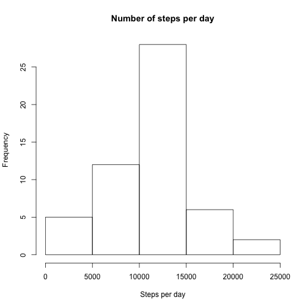

```r
hist(data2$steps, xlab = "Steps per day", main = "Number of steps per day")
```

Calculate and report the mean and median of the total number of steps taken per day

```r
print(mean(data2$steps))
```

```
## [1] 10766.19
```

```r
print(median(data2$steps))
```

```
## [1] 10765
```

# 3. What is the average daily activity pattern?

Calculate the average number of steps taken per interval

```r
data3 <- aggregate(steps ~ interval, data, mean)
```

Make a time series plot (i.e. type = “l”) of the 5-minute interval (x-axis) and the average number of steps taken, averaged across all days (y-axis)

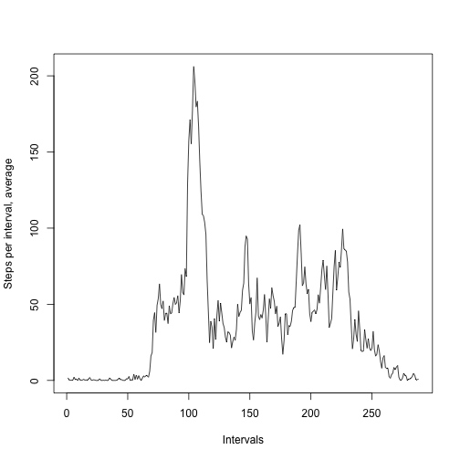

```r
plot(data3$steps, type = "l", xlab = "Intervals",
ylab = "Steps per interval, average")
```

```r
print(max(data3$steps))
```

```
## [1] 206.1698
```

```r
print(which.max(data3$steps))
```

```
## [1] 104
```

# 4. Imputing missing values

Calculate and report the total number of missing values in the dataset (i.e.the total number of rows with NAs)

```r
s <- sum(is.na(data$steps))
print(s)
```

```
## [1] 2304
```

Create a new dataset that is equal to the original dataset but with the missing data filled in. The strategy that I used was replacing the missing values with the mean for the corresponding 5-minute interval.

```r
names(data3)[2] <- "stepsMean"
new_data <- merge(data, data3, by = "interval", all.x = TRUE, sort = FALSE)
new_data2 <- new_data[with(new_data, order(new_data$date)), ]
v <- character(nrow(new_data2))
        for (i in c(1:nrow(new_data2))) {
            if (is.na(new_data2$steps[i]))
                {v[i] <- new_data2$stepsMean[i]}
                else {v[i] <- data$steps[i]}
                }
new_data2$imputedSteps <- v
new_data2$imputedSteps <- as.numeric(new_data2$imputedSteps)
new_data2$steps <- NULL
new_data2$stepsMean <- NULL
```

Make a histogram of the total number of steps taken each day and calculate and report the mean and median total number of steps taken per day.

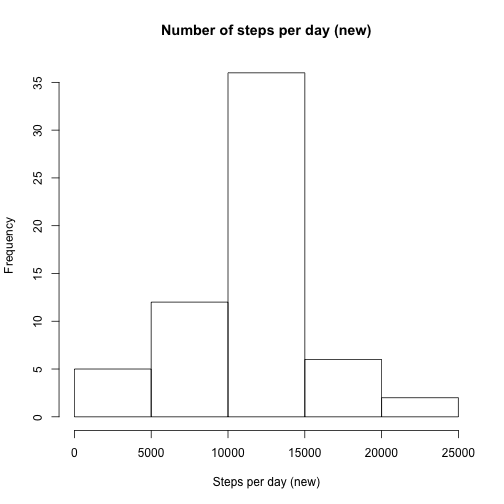

```r
data4 <- aggregate(imputedSteps ~ date, new_data2, sum)
hist(data4$imputedSteps, xlab = "Steps per day (new)",
main = "Number of steps per day (new)")
```

```r
print(mean(data4$imputedSteps))
```

```
## [1] 10766.19
```

```r
print(median(data4$imputedSteps))
```

```
## [1] 10766.19
```

# 5. Are there differences in activity patterns between weekdays and weekends?

```r
new_data2$date <- as.Date(new_data2$date)
new_data2$weekDay <- factor(weekdays(new_data2$date) %in% c("Monday", "Tuesday",
"Wednesday", "Thursday", "Friday"))
levels(new_data2$weekDay) <- c("Weekday", "Weekend")
```

Make a panel plot containing a time series plot (i.e. type = “l”) of the 5-minute interval (x-axis) and the average number of steps taken, averaged across all weekday days or weekend days (y-axis).

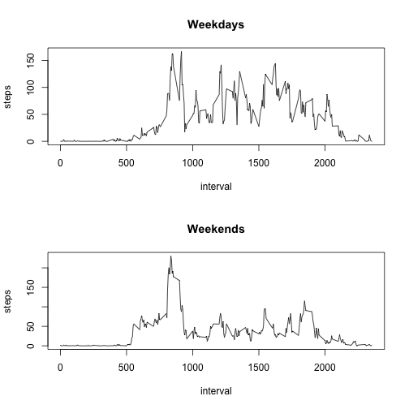

```r
dataWD <- new_data2[new_data2$weekDay == "Weekday", ]
dataWE <- new_data2[new_data2$weekDay == "Weekend", ]

dataWDmean <- aggregate(imputedSteps ~ interval, dataWD, mean)
dataWEmean <- aggregate(imputedSteps ~ interval, dataWE, mean)

par(mfrow = c(2,1))
with(dataWDmean, plot(interval, imputedSteps, type = "l", xlab = "interval",
ylab = "steps", main = "Weekdays"))
with(dataWEmean, plot(interval, imputedSteps, type = "l", xlab = "interval",
ylab = "steps", main = "Weekends"))
```